# Likelihood Notebook

Fred Viole

2023-02-02

# Likelihood of a Point

Since the probability of a specific point is 0, we need an interval $h$ such that $a = X-h$ and $b = X+h$. Current expanding window size of 0.0001 can serve as $h$.

$$P(a \leq X \leq b) = \int_a^b f(x)\ dx.$$

# Numerical Integration

We need to utilize numerical integration because we do not have continuous distributions with the 225 point submissions per MUID.

Partial moments:

$$LPM(1, target, f(x)) = \frac{1}{n} \sum_{i = 1}^N
max((-f(x_i)-target),0)$$

$$UPM(1, target, f(x)) = \frac{1}{n} \sum_{i = 1}^N max((f(x_i)-target),0)$$

Lebesgue (where $target = 0$):

$$f^-(x)=max({−𝑓(𝑥), 0})
= \begin{equation}
\begin{cases}
-f(x), & \text{if}\ f(x)<0 \\
0, & \text{otherwise}
\end{cases}
\end{equation}$$

$$f^+(x)=max({𝑓(𝑥), 0})
= \begin{equation}
\begin{cases}
f(x), & \text{if}\ f(x)>0 \\
0, & \text{otherwise}
\end{cases}
\end{equation}$$

In order to transform these `LPM and UPM` approximations of $\int f(x)dx$ into percentages, the `LPM.ratio()` is used. This is given by:

$$\frac{LPM(1, target, x)}{LPM(1, target, x) + UPM(1, target, x)}$$

where $LPM(1, target, x)$ is the approximate area of $x$ below a $target$ value, and $UPM(1, target, x)$ is the approximate area of $x$ above the same $target$ value, such that the denominator is the approximate total area.

Since $b > a$, we can simply difference these percentages below each point via:

`LPM.ratio(1, b, x) - LPM.ratio(1, a, x)`

`LPM.ratio()` code in R is available here: https://github.com/OVVO-Financial/NNS/blob/NNS-Beta-Version/src/partial_moments.cpp#L65

and the Python version is here: https://github.com/OVVO-Financial/NNS-Python/blob/master/NNS/Partial_Moments.py#L666

They are exceptionally efficient due to the C++ backend in R. I’m sure it would be trivial to convert these capabilities to Python.

# Highest Density Wins Pool

```r
library(NNS)

observed_value = 0.5
h = .02 # can be smaller, is larger for visualization on plots

b = observed_value + h
a = observed_value - h

set.seed(123)
MUID1 = rnorm(225)
MUID2 = rnorm(225, mean = 0, sd = 10)
MUID3 = rnorm(225, mean = 0, sd = .5)
MUID4 = rnorm(225, mean = .5, sd = .01) # if MUID nailed it



LPM.ratio(1, b, MUID1) - LPM.ratio(1, a, MUID1)
```

```
## [1] 0.01726409
```

```r
LPM.ratio(1, b, MUID2) - LPM.ratio(1, a, MUID2)
```

```
## [1] 0.002530282
```

```r
LPM.ratio(1, b, MUID3) - LPM.ratio(1, a, MUID3)
```

```
## [1] 0.01370177
```

```r
LPM.ratio(1, b, MUID4) - LPM.ratio(1, a, MUID4)
```

```
## [1] 0.9900673
```

MUID4 would win the pool due to its close distribution to the observed value.

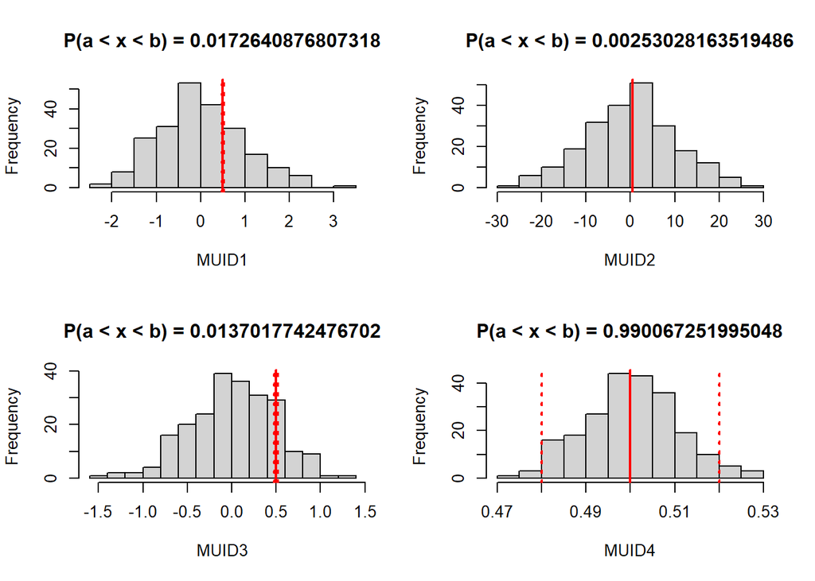

# Tail Observation

Notice, if the observation is not within the support of the submitted distribution, the result is 0.

```r
observed_value = 17.5

b = observed_value + h
a = observed_value - h

LPM.ratio(1, b, MUID1) - LPM.ratio(1, a, MUID1)
```

```
## [1] 0
```

```r
LPM.ratio(1, b, MUID2) - LPM.ratio(1, a, MUID2)
```

```
## [1] 0.0001195167
```

```r
LPM.ratio(1, b, MUID3) - LPM.ratio(1, a, MUID3)
```

```
## [1] 0
```

```r
LPM.ratio(1, b, MUID4) - LPM.ratio(1, a, MUID4)
```

```
## [1] 0
```

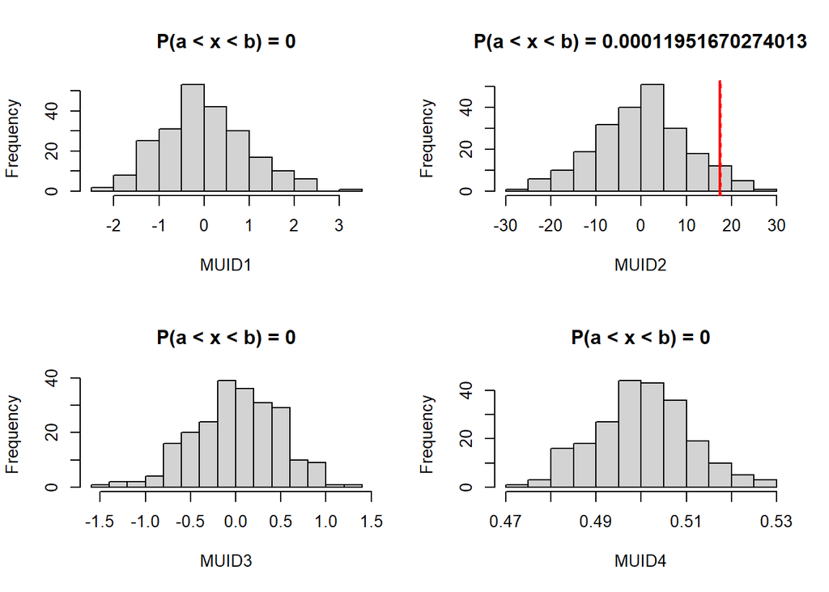

MUID2 would win this pool due to the fact that none of the other submissions even had this point in their distribution.

# Negative Values

Since `LPM.ratio` $\in [0,1]$ , negative observed values have no effect.

```r
observed_value = -0.5

b = observed_value + h
a = observed_value - h


MUID4 = rnorm(225, mean = -.5, sd = .01) # if MUID nailed it (again)


LPM.ratio(1, b, MUID1) - LPM.ratio(1, a, MUID1)
```

```
## [1] 0.01819097
```

```r
LPM.ratio(1, b, MUID2) - LPM.ratio(1, a, MUID2)
```

```
## [1] 0.002510503
```

```r
LPM.ratio(1, b, MUID3) - LPM.ratio(1, a, MUID3)
```

```
## [1] 0.01417299
```

```r
LPM.ratio(1, b, MUID4) - LPM.ratio(1, a, MUID4)
```

```
## [1] 0.9885166
```

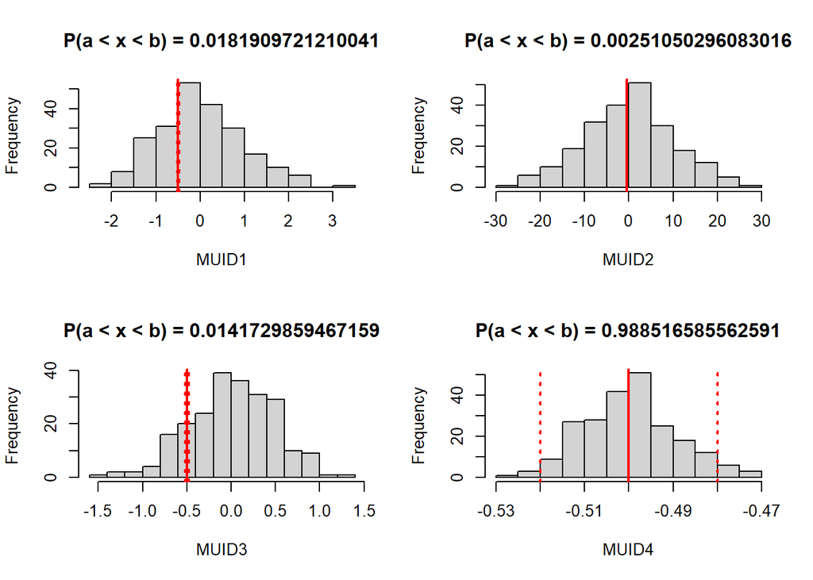

```r
observed_value = -17.5

b = observed_value + h
a = observed_value - h


LPM.ratio(1, b, MUID1) - LPM.ratio(1, a, MUID1)
```

```
## [1] 0
```

```r
LPM.ratio(1, b, MUID2) - LPM.ratio(1, a, MUID2)
```

```
## [1] 0.0001272613
```

```r
LPM.ratio(1, b, MUID3) - LPM.ratio(1, a, MUID3)
```

```
## [1] 0
```

```r
LPM.ratio(1, b, MUID4) - LPM.ratio(1, a, MUID4)
```

```
## [1] 0
```

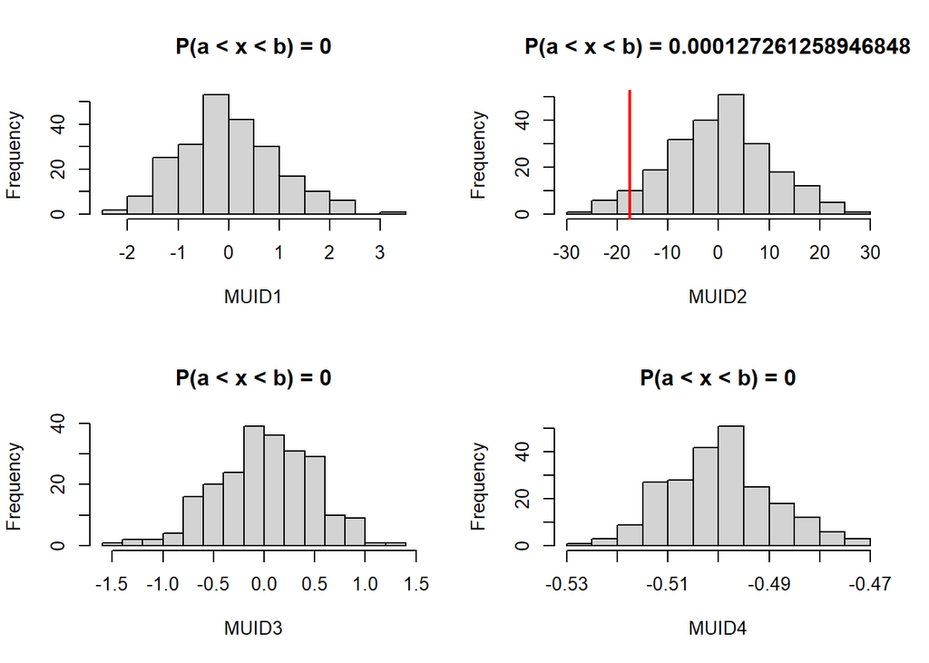